# 第5章 市場反応分析 (I)

## データ

#### sales-price-promo.txt

|  | 売上 | 価格 | 販促 |
| --- | --- | --- | --- |
| 1 | 2052 | 840 | 0 |
| 2 | 2105 | 820 | 0 |
| 3 | 2450 | 790 | 1 |
| 4 | 2131 | 780 | 0 |
| 5 | 2806 | 640 | 1 |
| 6 | 2532 | 710 | 0 |

- Import Dataset でデータを読み込む際，オプションの “Separator”（データの区切り）を “Whitespace”（スペース）に変更する
- データ読み込み時にファイル名のマイナス記号“-”は“.”に自動的に置き換えられる
- Macでデータ読み込み時に「不正なマルチバイト文字があります」とエラーが出る場合は，データファイルのエンコードをShif-JISからUTF-8に変更する
- **以下では教科書のデータをそのまま用いるが，本来であれば，エラーを防ぐためデータ内の日本語は避けた方がよい**

#### yogurt.txt

|  | Y1 | Y2 | X1 | X2 |
| --- | --- | --- | --- | --- |
| 1 | 173 | 537 | 145 | 145 |
| 2 | 223 | 384 | 139 | 145 |
| 3 | 271 | 309 | 144 | 154 |
| 4 | 280 | 364 | 145 | 152 |
| 5 | 235 | 452 | 136 | 142 |
| 6 | 150 | 498 | 143 | 153 |

## 3.2 散布図

```r
plot(x = sales.price.promo$価格, y = sales.price.promo$売上)
```

データセット内の特定の変数列を指定したいときは，「`"データ名"$"変数名"`」のように `$` でつなげて指定する。

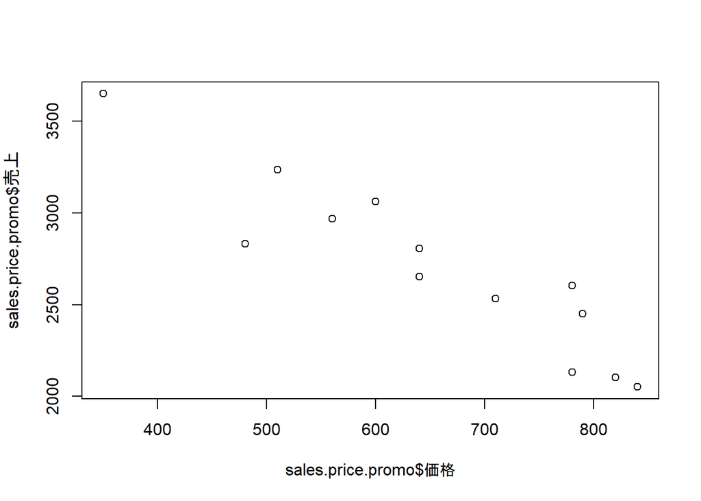

## 3.3 相関係数

```r
cor.test(x = sales.price.promo$価格, y = sales.price.promo$売上)
```

```
##
##  Pearson's product-moment correlation
##
## data:  sales.price.promo$価格 and sales.price.promo$売上
## t = -8.1457, df = 11, p-value = 5.5e-06
## alternative hypothesis: true correlation is not equal to 0
## 95 percent confidence interval:
##  -0.9780506 -0.7661642
## sample estimates:
##        cor
## -0.9261709
```

## 4 単回帰モデル

```r
# 回帰分析の実行
result1 <- lm(売上 ~ 価格, data = sales.price.promo)

# 推定結果の表示
summary(result1)
```

**`lm(formula, data)`：線形回帰モデルの推定**

- **`formula`**：目的変数・説明変数の指定
  - 「目的変数 ~ 説明変数1 + 説明変数2 + 説明変数3」のように，`~` の左側に目的変数，右側に説明変数を記述する
  - 説明変数が2個以上ある場合は，`+` で追加する
- **`data`**：分析データの指定

`lm` の実行結果は `<-` の左側のオブジェクト（上の例では `result1`）に入っており，`summary` で結果を表示することができる。 特定の結果のみ抜き出したいときは専用の関数が用意されている。「4.1 信頼係数」では `result1` から `confint` 関数で回帰係数の95%区間を抜き出している。 詳細は `?lm` を実行して `lm` 関数のヘルプを参照。

```
##
## Call:
## lm(formula = 売上 ~ 価格, data = sales.price.promo)
##
## Residuals:
##     Min      1Q  Median      3Q     Max
## -368.25 -110.38   -0.84  124.15  269.81
##
## Coefficients:
##              Estimate Std. Error t value Pr(>|t|)
## (Intercept) 4581.7523   236.7640  19.352 7.61e-10 ***
## 価格          -2.8802     0.3536  -8.146 5.50e-06 ***
## ---
## Signif. codes:  0 '***' 0.001 '**' 0.01 '*' 0.05 '.' 0.1 ' ' 1
##
## Residual standard error: 184.1 on 11 degrees of freedom
## Multiple R-squared:  0.8578, Adjusted R-squared:  0.8449
## F-statistic: 66.35 on 1 and 11 DF,  p-value: 5.5e-06
```

## 4.1 信頼係数

```r
confint(result1, level = 0.95)
```

```
##                   2.5 %      97.5 %
## (Intercept) 4060.638183 5102.866414
## 価格          -3.658452   -2.101967
```

## 4.4 売上の予測

教科書では手計算で予測値を求めているが，R上で予測用データを作成して予測を実行することができる。説明変数が多い場合は，Rで予測を行った方が正確である。

```r
# 予測用の価格データの作成
newprice <- data.frame(価格 = 350)

# 予測の実行
predict(result1, newdata = newprice)
```

```
##        1
## 3573.679
```

注：教科書との数値の差は小数点4桁以上を計算に利用しているかどうか

## 5 重回帰モデル

```r
result2 <- lm(売上 ~ 価格 + 販促, data = sales.price.promo)
summary(result2)
```

```
##
## Call:
## lm(formula = 売上 ~ 価格 + 販促, data = sales.price.promo)
##
## Residuals:
##      Min       1Q   Median       3Q      Max
## -182.876  -54.165    0.597   63.301  162.349
##
## Coefficients:
##              Estimate Std. Error t value Pr(>|t|)
## (Intercept) 4263.2262   148.6279  28.684 6.18e-11 ***
## 価格          -2.6028     0.2077 -12.531 1.94e-07 ***
## 販促         297.1607    60.1706   4.939 0.000588 ***
## ---
## Signif. codes:  0 '***' 0.001 '**' 0.01 '*' 0.05 '.' 0.1 ' ' 1
##
## Residual standard error: 104.1 on 10 degrees of freedom
## Multiple R-squared:  0.9586, Adjusted R-squared:  0.9504
## F-statistic: 115.9 on 2 and 10 DF,  p-value: 1.209e-07
```

## 6.3 交差価格弾力性

```r
result3 <- lm(log(Y1) ~ log(X1) + log(X2), data = yogurt)   # log()で対数変換
summary(result3)
```

```
##
## Call:
## lm(formula = log(Y1) ~ log(X1) + log(X2), data = yogurt)
##
## Residuals:
##      Min       1Q   Median       3Q      Max
## -0.52555 -0.13583 -0.05818  0.18692  0.38784
##
## Coefficients:
##             Estimate Std. Error t value Pr(>|t|)
## (Intercept)    7.720      7.097   1.088    0.286
## log(X1)       -7.033      1.290  -5.451 9.08e-06 ***
## log(X2)        6.504      1.187   5.479 8.42e-06 ***
## ---
## Signif. codes:  0 '***' 0.001 '**' 0.01 '*' 0.05 '.' 0.1 ' ' 1
##
## Residual standard error: 0.2199 on 27 degrees of freedom
## Multiple R-squared:  0.6221, Adjusted R-squared:  0.5941
## F-statistic: 22.22 on 2 and 27 DF,  p-value: 1.973e-06
```